```python
import numpy as np
import matplotlib.pyplot as plt
import matplotlib.colors as colors
from IPython.display import YouTubeVideo, Markdown, Code
%matplotlib inline
```

# NumPy: A look at the past, present, and future of array computation

[Ross Barnowski](https://bids.berkeley.edu/people/ross-barnowski) `rossbar@berkeley.edu` | [@rossbar](https://github.com/rossbar) on GitHub

University of Michigan EECS | 1/30/2020

# Part I - Overview

# What is NumPy?

> *NumPy is the fundamental package for scientific computing with Python*

> [numpy.org](https://numpy.org/)

Strong stuff.

## The scientific Python ecosystem

[figure not shown]

Image credit: [Jake VanderPlas](http://vanderplas.com/) **circa 2015**

# A bit of history

- **Mid 90's/Early 00's**: desire for high-performance numerical computation in Python eventually culminates in the [`Numeric`](https://numpy.org/_downloads/768fa66c250a0335ad3a6a30fae48e34/numeric-manual.pdf) library
- Early adopters included the [Space Telescope Science Institute (STScI)](http://www.stsci.edu/) who developed another array computation package to better suit their needs: `NumArray`.
- **2005** The best ideas from `Numeric` and `NumArray` were combined in the development of a new library, `NumPy`
  - This work was largely done by [Travis Oliphant](https://github.com/teoliphant), then an assistant professor at BYU
- **2006** NumPy v1.0 released in October

[NumPy Development History](https://github.com/numpy/numpy/graphs/contributors)

# What does NumPy provide?

- `ndarray`: A generic, n-dimensional array data structure
- Sophisticated machinery for operating on array data
  - Powerful indexing
  - Built-in, array-aware operations
  - Vectorization and broadcasting
- All features exposed by a concise, expressive syntax
- Language extension/integration (C-API, `f2py`) and interoperability
  - [Array API](https://numpy.org/doc/1.17/reference/c-api.array.html) for accessing/extending array functionality
  - Protocols for replicating the NumPy interface (stay tuned...)

## What else?

`numpy` also includes tools for common scientific/numerical tasks:

- Random number generation (`np.random`)
- Fourier analysis (`np.fft`)
- Linear algebra (`np.linalg`)

### The `scipy` package includes modules with the same name? What's the deal?

## A useful analogy...

[figure not shown]

- E.g. see [this quick comparison](https://numpy.org/devdocs/reference/routines.linalg.html) of the `numpy` and `scipy` `linalg` modules.

# Where is NumPy used?

# At a glance

[figure not shown]

**See also**: [Anaconda 2019 Year in Review](https://www.anaconda.com/2019-year-in-review/), [NumPy PyPI Stats page](https://pypistats.org/packages/numpy)

# Part II - NumPy in the wild

# Generating the first ever direct image of a black hole

On April 10th 2019, the [Event Horizon Telescope](https://eventhorizontelescope.org/) collaboration released the [first ever image of a black hole](https://eventhorizontelescope.org/press-release-april-10-2019-astronomers-capture-first-image-black-hole):

[figure not shown]

Image source: The [official blog post](https://eventhorizontelescope.org/press-release-april-10-2019-astronomers-capture-first-image-black-hole) from the EHT collaboration announcing the result

The data and analysis pipeline are *way* too complicated to cover in a few slides.

Instead, we'll just take advantage of the fact that the imaging pipeline is built on the tools of the scientific python ecosystem:

[figure not shown]

Image credit: [Shaloo Shalini (@shaloo)](https://github.com/shaloo). For info on how this graphic was created, check out [shaloo's script](https://github.com/numpy/numpy.org/pull/23).

Let's run [the eht imaging pipeline](https://github.com/eventhorizontelescope/2019-D01-02) provided by the Event Horizons collaborators to help produce images from their [calibrated data](https://github.com/eventhorizontelescope/2019-D01-01).

These repos with the helper-script for running the pipeline and the calibrated data have been included as submodules in `event_horizon_example/`.

```python
%run event_horizons_example/2019-D01-02/eht-imaging/eht-imaging_pipeline.py  -i event_horizons_example/2019-D01-01/uvfits/SR1_M87_2017_101_lo_hops_netcal_StokesI.uvfits
```

[output not shown]

[output not shown]

[output cut: 118 more lines]

[output not shown]

See? ...It's complicated. Here's the result:

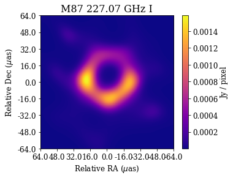

```python
fig = im_out.display(cfun=plt.cm.plasma)
```